# Research Methods (year 1) – Visualization Walk through

Jens Roeser

August 22 2019

# Starting Rstudio

Start Rstudio on your computer and open a new script: click on `File > New File > R Script` (or press CTRL+SHIFT+N).

Load the package `tidyverse` by typing …

```r
library(tidyverse)
```

… and press CTRL+ENTER with the cursor in the the line of code you want to run. `tidyverse` includes many useful functions including the plotting function `ggplot`.

Then, tell R where your data are saved on your computer. In the tab menu above click on: `Session > Set Working Directory > Choose Directory ...` and browse to the directory with your data and click on `Open`. There will be a function appearing in the console `setwd(...)`.

# Loading Data

Load the data frame into a variable, here `Df`.

```r
Df <- read_csv("data.csv")
```

If that doesn’t work try the following. In Rstudio’s panels you will find an `Environment` tap: click on `Environment > Import Dataset` and choose the option `From Text (readr) ...` or if your data are stored in an Excel sheet `From Excel ...`. Browse to your data file and in `Import Options:` change the `Name` to the target variable `Df`.

Have a quick peak at the data by typing `Df` into the console.

```r
Df
```

```
## # A tibble: 384 x 5
##    Expression Sex   Attractiveness   Lab Table
##    <chr>      <chr>          <dbl> <dbl> <chr>
##  1 Happy      Male            14.8     1 T1
##  2 Happy      Male            17.2     1 T1
##  3 Happy      Male            13.9     1 T1
##  4 Happy      Male            14.9     1 T1
##  5 Happy      Male            18.4     1 T1
##  6 Happy      Male            16.7     1 T1
##  7 Happy      Male            12.4     1 T2
##  8 Happy      Male            17.0     1 T2
##  9 Happy      Male            13.8     1 T2
## 10 Happy      Male            13.8     1 T2
## # ... with 374 more rows
```

# Plotting the data

For visualization of the attractiveness ratings we use `ggplot` and Box-and-Whisker plots (box plots).

## Cohort level visualization

In the first plot we visualize the attractiveness ratings on the cohort level, hence across lab groups. For this visualization we need to include all our main variables of interest, i.e. the attractiveness ratings, sex of image (male, female) and expression (happy, unhappy). The plotting function `ggplot` needs two main arguments, the name of the variable that contains the data frame (`data = Df`) and aesthetics (`aes()`) which are the mappings between our variables of interest and the graph features (such as colour, x-axis, y-axis).

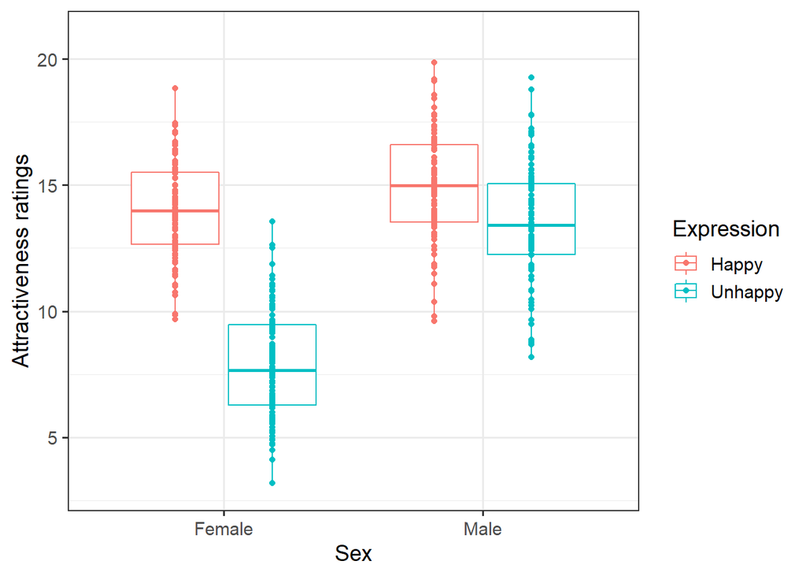

```r
ggplot(data = Df, aes(y = Attractiveness, x = Sex, colour = Expression)) +
  geom_boxplot() +
  geom_point(position = position_dodge(.75)) +
  theme_bw(base_size = 14) +
  labs(y = "Attractiveness ratings") +
  ylim(3, 21)
```

In the example we map `Attractiveness` onto the y-axis, `Sex` onto the x-axis and `Expression` should be distinguished by `colour`. The data are rendered by `geom_boxplot` and `geom_point`. `geom` is short for geometrics which controls the way data are visualized (e.g. box plots, bars, lines, points). In our example, the data are shown as box plots and points. Notice `position = position_dodge(.75)`. This argument of `geom_points` ensures that the data points horizontally overlap with the box plots.

This already creates a basic plot. The next piece of code `theme_bw(base_size = 14)` changes the default customization of components of the plot that are not the data (e.g. background colour, frame, grid). `base_size = 14` increases the font size. Try and remove this bit for plotting to see the change. Try also other themes such as `theme_light()` and `theme_minial()`.

The name of the y-label was changes to *Attractiveness ratings* using `labs(y = "Attractiveness ratings")` and the scale of the y-axis was extended to range from 3 to 21 using `ylim(3, 21)` which are the minimum and maximum score, respectively.

Aside, note that all these bits need to be combined with a plus sign `+`.

## Lab level visualization

In the next step we plot the data for each lab group individually. First we make a small tweak the `Lab` variable. The function `paste0` adds the number of each lab (1, 2, …) to the string *Lab group:* and then assigns it (`<-`) to the old variable `Df$Lab`.

```r
Df$Lab <- paste0("Lab group: ", Df$Lab)
```

Check below how the variable has changed and compare to the `Df` output above.

```r
Df
```

```
## # A tibble: 384 x 5
##    Expression Sex   Attractiveness Lab          Table
##    <chr>      <chr>          <dbl> <chr>        <chr>
##  1 Happy      Male            14.8 Lab group: 1 T1
##  2 Happy      Male            17.2 Lab group: 1 T1
##  3 Happy      Male            13.9 Lab group: 1 T1
##  4 Happy      Male            14.9 Lab group: 1 T1
##  5 Happy      Male            18.4 Lab group: 1 T1
##  6 Happy      Male            16.7 Lab group: 1 T1
##  7 Happy      Male            12.4 Lab group: 1 T2
##  8 Happy      Male            17.0 Lab group: 1 T2
##  9 Happy      Male            13.8 Lab group: 1 T2
## 10 Happy      Male            13.8 Lab group: 1 T2
## # ... with 374 more rows
```

To visualize the the data by lab group we make one small change to the code above, everything else remains the same. We add `facet_wrap(~Lab)`. This creates subplots for each lab group as you can see below. In contrast to `facet_grid(~Lab)` the panels are not forced to be next to each other as you will see in the next section.

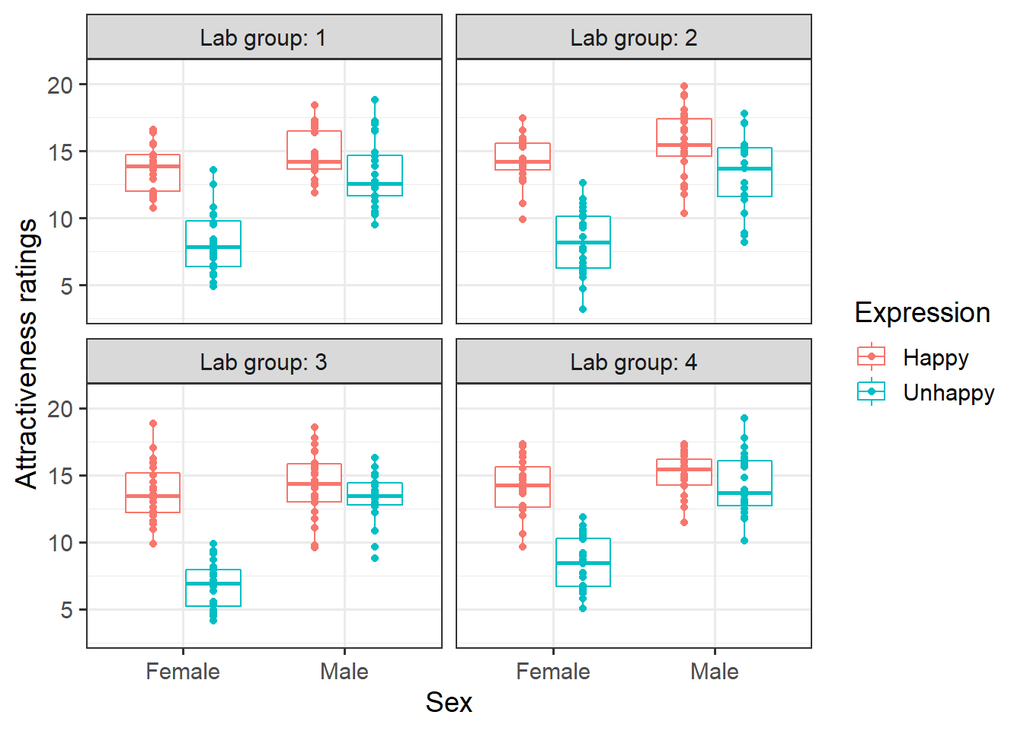

```r
ggplot(data = Df, aes(y = Attractiveness, x = Sex, colour = Expression)) +
  geom_boxplot() +
  geom_point(position = position_dodge(.75)) +
  theme_bw(base_size = 14) +
  labs(y = "Attractiveness ratings") +
  ylim(3, 21) +
  facet_wrap(~Lab)
```

There are different groups within each lab. We can add these to the plot. Again, the code below is the same as above with one minor tweak. Instead of using `facet_wrap(~Lab)` we changed this to `facet_grid(Lab~Table)`. As you can see, this function separates the plotting for lab groups (vertical axis) and tables (horizontal axis).

There is one small change. `theme()` can be used to change visual features. In the code below we moved the position of the legend to the top of the plot (`legend.position = "top"`) and to the right side (`legend.justification = "right"`).

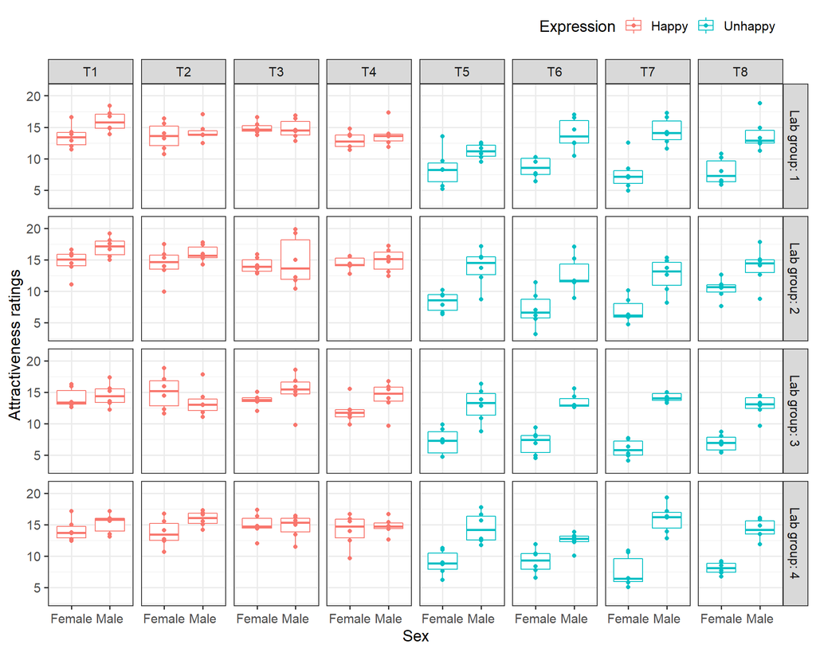

```r
ggplot(data = Df, aes(y = Attractiveness, x = Sex, colour = Expression)) +
  geom_boxplot() +
  geom_point(position = position_dodge(.75)) +
  theme_bw(base_size = 14) +
  labs(y = "Attractiveness ratings") +
  ylim(3, 21) +
  facet_grid(Lab~Table) +
  theme(legend.position = "top",
        legend.justification = "right")
```

## Visualizing subgroups

Sometimes we are only interested in subgroups of the data. To visualize only subgroups we can restrict the plotting to subsets of the data by filtering the data for the levels your are interested in.

To pick a subset of our data `Df` we can use the function `filter`. `filter` needs to know the name of the data frame `Df` and the way it should subset it. In this example we select only lab group 1 (`Lab == "Lab group: 1"`). Remember that we changed the values of `Lab` above. All other lab groups were removed. The output of this is stored in a new variable called `lab1`. Notice that we used `==` instead of `=`. This is because `=` is used for arguments and assignments and `==` is a logical operator for *is equal to*.

```r
lab1 <- filter(Df, Lab == "Lab group: 1")
```

The ggplot below is the same as the first plot, except we use the subsetted data frame `lab1` instead of `Df` (see `data = lab1`).

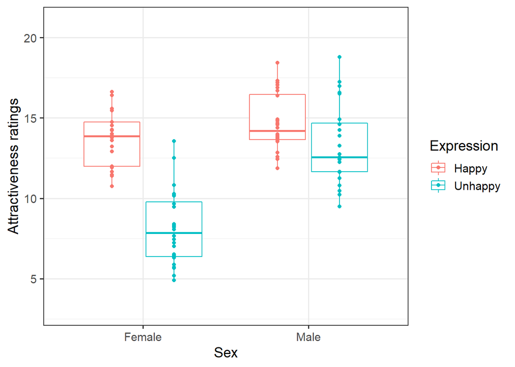

```r
ggplot(data = lab1, aes(y = Attractiveness, x = Sex, colour = Expression)) +
  geom_boxplot() +
  geom_point(position = position_dodge(.75)) +
  theme_bw(base_size = 14) +
  labs(y = "Attractiveness ratings") +
  ylim(3, 21)
```

As before we can display the data individually for each table in lab group 1 by adding `facet_wrap(~Table, ncol = 4)`. `ncol = 4` makes sure that we show 4 columns next to each other.

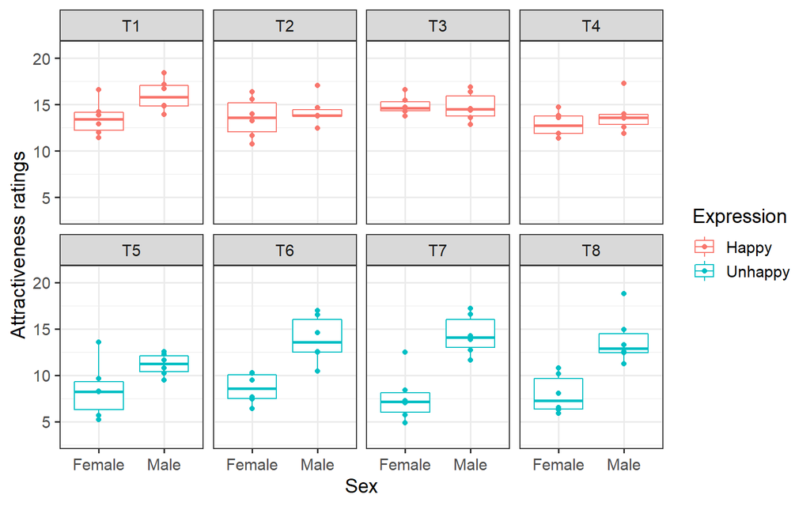

```r
ggplot(data = lab1, aes(y = Attractiveness, x = Sex, colour = Expression)) +
  geom_boxplot() +
  geom_point(position = position_dodge(.75)) +
  theme_bw(base_size = 14) +
  labs(y = "Attractiveness ratings") +
  ylim(3, 21) +
  facet_wrap(~Table, ncol = 4)
```

We can subset the data even further. This time let’s pick to tables, table T1 and T5 from lab group 1 (`lab1`). If you were to select only one table, you could use `filter(lab1, Table == "T1")`. If we want to select two tables we need `%in%` which tests whether a given value is *in* `Table` and `c()` which is the *concatenate* function because we need want to select more than one value.

```r
labgroup <- filter(lab1, Table %in% c("T1", "T5"))
```

The plotting function is the same as the previous one (except, we omitted `ncol=4`).

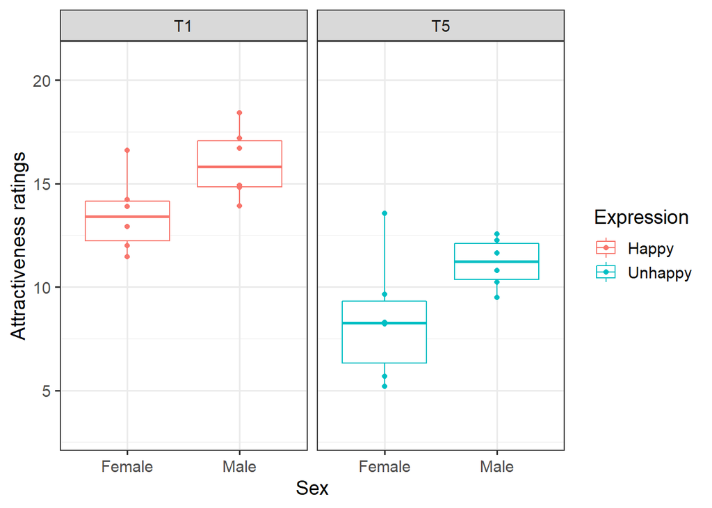

```r
ggplot(data = labgroup, aes(y = Attractiveness, x = Sex, colour = Expression)) +
  geom_boxplot() +
  geom_point(position = position_dodge(.75)) +
  theme_bw(base_size = 14) +
  labs(y = "Attractiveness ratings") +
  ylim(3, 21) +
  facet_wrap(~Table)
```

# Saving your plot

To save a plot use `ggsave()` after creating the plot you want to save. `ggsave()` will save the plot that is currently open. The plot will be saved with the name *myplot* (change the name to something more comprehensive) as .png file in the location that you selected in the beginning. If you are not sure where that is type `getwd()` into your console.

```r
ggsave("myplot.png")
```

To change the size of the plot you can modify the width and height.

```r
ggsave("myplot.png", width = 6, height = 4)
```